# ¿Cómo manipular funciones?

```python
import numpy as np
import matplotlib.pyplot as plt

#Configurando Latex
# Configuración de Matplotlib para usar LaTeX
plt.rcParams.update({
    "text.usetex": True,
    "font.family": "serif",
    "font.serif": ["Computer Modern Roman"],
    "text.latex.preamble": r"\usepackage{amsmath}"
})
```

## Desplazamientos

Siendo $c$ una constante mayor que cero, entonces la gráfica:

### Vertical

- $y=f(x)+c$ se desplaza $c$ unidades hacia arriba.
- $y=f(x)-c$ se desplaza $c$ unidades hacia abajo.

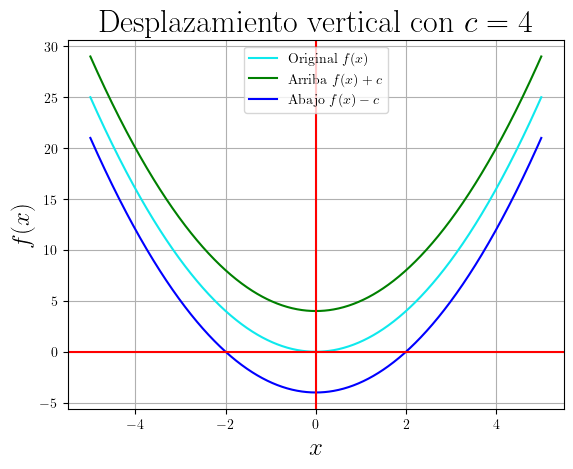

```python
# definiendo funcion parabola
def f(x):
  return x**2

#Definiendo variables
N = 1000
c = 4
x = np.linspace(-5,5, num=N)

#Creando graficas
fig, ax = plt.subplots()
ax.plot(x,f(x),label=r'Original $f(x)$',color='#0EE9ED')
ax.plot(x,f(x)+c,label=r'Arriba $f(x)+c$',color='green')
ax.plot(x,f(x)-c,label=r'Abajo $f(x)-c$',color='blue')
ax.grid()
ax.axhline(y=0, color='r')
ax.axvline(x=0, color='r')
plt.title(r'Desplazamiento vertical con $c=4$',fontsize=23)
plt.xlabel(r'$x$',fontsize=18)
plt.ylabel(r'$f(x)$',fontsize=18)
plt.legend()
plt.show()
```

### Horizontal

- $y=f(x-c)$ se desplaza $c$ unidades hacia la derecha.
- $y=f(x+c)$ se desplaza $c$ unidades hacia la izquierda.

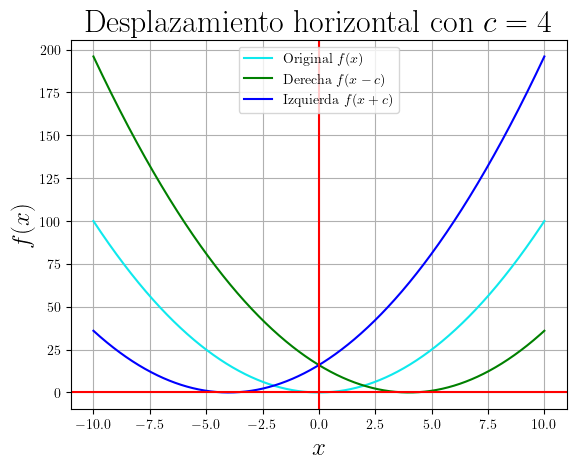

```python
# definiendo funcion parabola
def f(x):
  return x**2

#Definiendo variables
N = 1000
c = 4
x = np.linspace(-10,10, num=N)

#Creando graficas
fig, ax = plt.subplots()
ax.plot(x,f(x),label=r'Original $f(x)$',color='#0EE9ED')
ax.plot(x,f(x-c),label=r'Derecha $f(x-c)$',color='green')
ax.plot(x,f(x+c),label=r'Izquierda $f(x+c)$',color='blue')
ax.grid()
ax.axhline(y=0, color='r')
ax.axvline(x=0, color='r')
plt.title(r'Desplazamiento horizontal con $c=4$',fontsize=23)
plt.xlabel(r'$x$',fontsize=18)
plt.ylabel(r'$f(x)$',fontsize=18)
plt.legend()
plt.show()
```

## Alargamientos y compresiones

Siendo $c$ una constante mayor que cero, entonces la gráfica:

#### NOTA:

- **Alargamiento:** nos referimos a que el valor incrementa más rápido, según en el eje $x$ o $y$ planteado.
- **Compresión:** nos referimos a que el valor incrementa más lento, según en el eje $x$ o $y$ planteado.

### Vertical

- $y=c \cdot f(x)$ alarga la gráfica verticalmente en un factor de $c$.
- $y= \frac{1}{c} \cdot f(x)$ comprime la gráfica verticalmente en un factor de $c$.

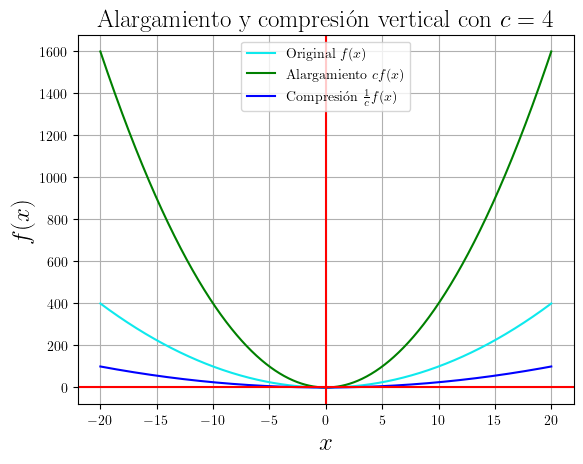

```python
# definiendo funcion parabola
def f(x):
  return x**2

#Definiendo variables
N = 1000
c = 4
x = np.linspace(-20,20, num=N)

#Creando graficas de Compresion y alargamiento
fig, ax = plt.subplots()
ax.plot(x,f(x),label=r'Original $f(x)$',color='#0EE9ED')
ax.plot(x,c*f(x),label=r'Alargamiento $cf(x)$',color='green')
ax.plot(x,(1/c)*f(x),label=r'Compresión $\frac{1}{c} f(x)$',color='blue')
ax.grid()
ax.axhline(y=0, color='r')
ax.axvline(x=0, color='r')
plt.title(r'Alargamiento y compresión vertical con $c=4$',fontsize=18)
plt.xlabel(r'$x$',fontsize=18)
plt.ylabel(r'$f(x)$',fontsize=18)
plt.legend()
plt.show()
```

### Horizontal

- $y=f(c \cdot x)$ comprime la gráfica horizontalmente en un factor de $c$.
- $y= f(\frac{1}{c} \cdot x )$ alarga la gráfica horizontalmente en un factor de $c$.

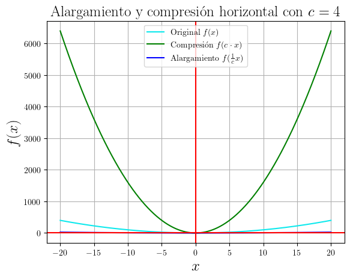

```python
# definiendo funcion parabola
def f(x):
  return x**2

#Definiendo variables
N = 1000
c = 4
x = np.linspace(-20,20, num=N)

#Creando graficas de Compresion y alargamiento
fig, ax = plt.subplots()
ax.plot(x,f(x),label=r'Original $f(x)$',color='#0EE9ED')
ax.plot(x,f(c*x),label=r'Compresión $f(c\cdot x)$',color='green')
ax.plot(x,f((1/c)*x),label=r'Alargamiento $f(\frac{1}{c} x)$',color='blue')
ax.grid()
ax.axhline(y=0, color='r')
ax.axvline(x=0, color='r')
plt.title(r'Alargamiento y compresión horizontal con $c=4$',fontsize=18)
plt.xlabel(r'$x$',fontsize=18)
plt.ylabel(r'$f(x)$',fontsize=18)
plt.legend()
plt.show()
```

## NOTA

Debido a que la parbóla no es buena para representar este tipo de comportamiento, usaré una función $seno(x)$ con el mismo código planteado, lo único que se le cambiará es el retorno del valor de `f(x)`

### Vertical

- $y=c \cdot f(x)$ alarga la gráfica verticalmente en un factor de $c$.
- $y= \frac{1}{c} \cdot f(x)$ comprime la gráfica verticalmente en un factor de $c$.

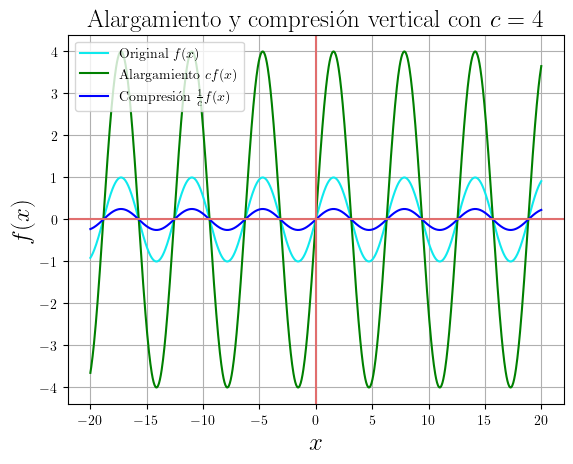

```python
# definiendo funcion seno
def f(x):
  return np.sin(x)

#Definiendo variables
N = 1000
c = 4
x = np.linspace(-20,20, num=N)

#Creando graficas de Compresion y alargamiento
fig, ax = plt.subplots()
ax.plot(x,f(x),label=r'Original $f(x)$',color='#0EE9ED')
ax.plot(x,c*f(x),label=r'Alargamiento $cf(x)$',color='green')
ax.plot(x,(1/c)*f(x),label=r'Compresión $\frac{1}{c} f(x)$',color='blue')
ax.grid()
ax.axhline(y=0, color='#E16E6E')
ax.axvline(x=0, color='#E16E6E')
plt.title(r'Alargamiento y compresión vertical con $c=4$',fontsize=18)
plt.xlabel(r'$x$',fontsize=18)
plt.ylabel(r'$f(x)$',fontsize=18)
plt.legend()
plt.show()
```

### Compresión horizontal

- $y=f(c \cdot x)$ comprime la gráfica horizontalmente en un factor de $c$.

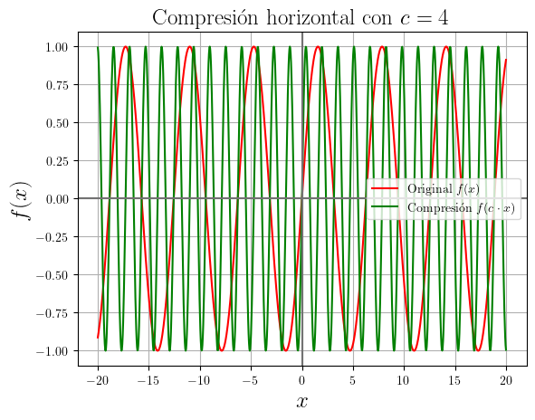

```python
# definiendo funcion seno(x)
def f(x):
  return np.sin(x)

#Definiendo variables
N = 1000
c = 4
x = np.linspace(-20,20, num=N)

#Creando graficas de Compresion y alargamiento
fig, ax = plt.subplots()
ax.plot(x,f(x),label=r'Original $f(x)$',color='red')
ax.plot(x,f(c*x),label=r'Compresión $f(c\cdot x)$',color='green')
ax.grid()
ax.axhline(y=0, color='#727272')
ax.axvline(x=0, color='#727272')
plt.title(r'Compresión horizontal con $c=4$',fontsize=18)
plt.xlabel(r'$x$',fontsize=18)
plt.ylabel(r'$f(x)$',fontsize=18)
plt.legend()
plt.show()
```

### Alargamiento horizontal

- $y= f(\frac{1}{c} \cdot x )$ alarga la gráfica horizontalmente en un factor de $c$.

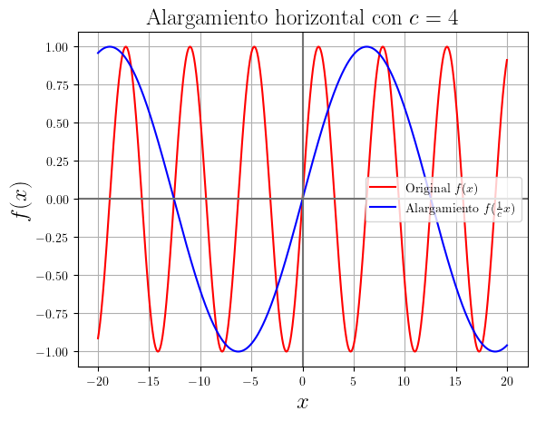

```python
# definiendo funcion seno(x)
def f(x):
  return np.sin(x)

#Definiendo variables
N = 1000
c = 4
x = np.linspace(-20,20, num=N)

#Creando graficas de Compresion y alargamiento
fig, ax = plt.subplots()
ax.plot(x,f(x),label=r'Original $f(x)$',color='red')
ax.plot(x,f((1/c)*x),label=r'Alargamiento $f(\frac{1}{c} x)$',color='blue')
ax.grid()
ax.axhline(y=0, color='#727272')
ax.axvline(x=0, color='#727272')
plt.title(r'Alargamiento horizontal con $c=4$',fontsize=18)
plt.xlabel(r'$x$',fontsize=18)
plt.ylabel(r'$f(x)$',fontsize=18)
plt.legend()
plt.show()
```

## Reflexiones

### Horizontal

- $y=-f(x)$ refleja la gráfica respecto al eje x.

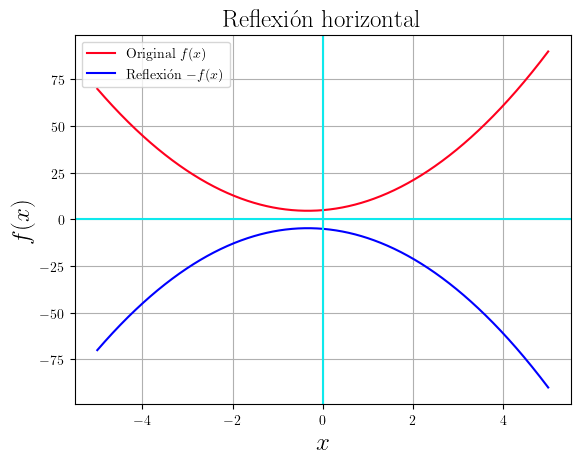

```python
# definiendo funcion lineal
def f(x):
  y=( 3*(x**2) + (2*x) + 5)
  return y

#Definiendo variables
N = 1000
x = np.linspace(-5,5, num=N)

#Creando graficas de Compresion y alargamiento
fig, ax = plt.subplots()
ax.plot(x,f(x),label=r'Original $f(x)$',color='#FF001E')
ax.plot(x,-1*f(x),label=r'Reflexión $-f(x)$',color='blue')
ax.grid()
ax.axhline(y=0, color='#0EE9ED')
ax.axvline(x=0, color='#0EE9ED')
plt.title(r'Reflexión horizontal',fontsize=18)
plt.xlabel(r'$x$',fontsize=18)
plt.ylabel(r'$f(x)$',fontsize=18)
plt.legend()
plt.show()
```

### Vertical

- $y=f(-x)$ refleja la gráfica respecto al eje y.

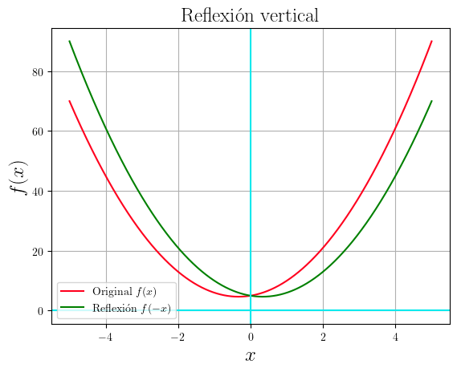

```python
# definiendo funcion lineal
def f(x):
  y=( 3*(x**2) + (2*x) + 5)
  return y

#Definiendo variables
N = 1000
x = np.linspace(-5,5, num=N)

#Creando graficas de Compresion y alargamiento
fig, ax = plt.subplots()
ax.plot(x,f(x),label=r'Original $f(x)$',color='#FF001E')
ax.plot(x,f(-1*x),label=r'Reflexión $f(-x)$',color='green')
ax.grid()
ax.axhline(y=0, color='#0EE9ED')
ax.axvline(x=0, color='#0EE9ED')
plt.title(r'Reflexión vertical ',fontsize=18)
plt.xlabel(r'$x$',fontsize=18)
plt.ylabel(r'$f(x)$',fontsize=18)
plt.legend()
plt.show()
```

### Comparación de ambos

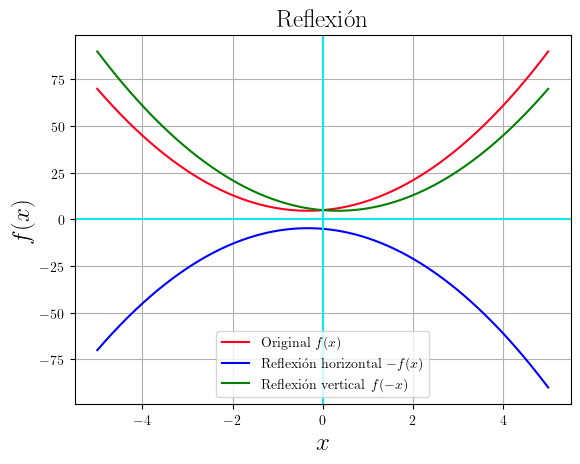

```python
# definiendo funcion lineal
def f(x):
  y=( 3*(x**2) + (2*x) + 5)
  return y

#Definiendo variables
N = 1000
x = np.linspace(-5,5, num=N)

#Creando graficas de Compresion y alargamiento
fig, ax = plt.subplots()
ax.plot(x,f(x),label=r'Original $f(x)$',color='#FF001E')
ax.plot(x,-1*f(x),label=r'Reflexión horizontal $-f(x)$',color='blue')
ax.plot(x,f(-1*x),label=r'Reflexión vertical $f(-x)$',color='green')
ax.grid()
ax.axhline(y=0, color='#0EE9ED')
ax.axvline(x=0, color='#0EE9ED')
plt.title(r'Reflexión ',fontsize=18)
plt.xlabel(r'$x$',fontsize=18)
plt.ylabel(r'$f(x)$',fontsize=18)
plt.legend()
plt.show()
```

### Explicación:

Cuando hablamos de reflexión, es bueno verlo como:

- Vertical: Gira sobre el **eje y**.
- Horizontal: Gira sobre el **eje x**.